# Project Part 4

## Random Forest model - predictive ability

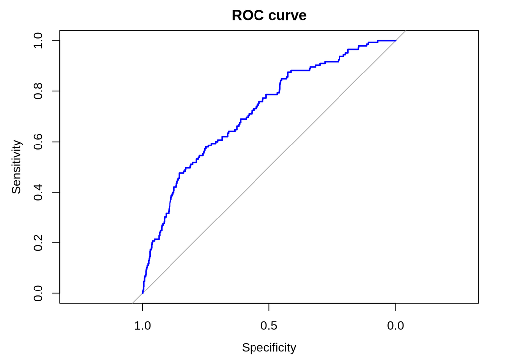

```r
o.pred <- predict(my_random_forest, test_data_rf, OOB = TRUE)
roc <- roc(test_data_rf$EVENT, o.pred$predicted)
auc <- auc(roc)
plot(roc, col = "blue", lwd = 2, main = "ROC curve")
```

```r
print(auc)
```

```
Area under the curve: 0.7196
```

The graph above shows the ROC curve of the random forest model applied in this assignment. The curve rises above the diagonal grey line, indicating that our model is performing better than random guessing, logically. The AUC of our model resulted in an amount of 0.7196; This means that our Random Forest classifier is performing well.

## Final model - Whole dataset

```r
final_model_params <- tune.rfsrc(EVENT ~ .,
    data = dataset_rf,
    ntree = 100, nodedepth = 5, seed = 123
)

final_model <- rfsrc(EVENT ~ .,
    data = dataset_rf,
    ntree = 100,
    nodedepth = 5,
    seed = 123,
    nodesize = final_model_params$optimal["nodesize"],
    mtry = final_model_params$optimal["mtry"],
    importance = TRUE
)

print(final_model)
```

```
                         Sample size: 3873
                     Number of trees: 100
           Forest terminal node size: 10
       Average no. of terminal nodes: 24.41
No. of variables tried at each split: 29
              Total no. of variables: 29
       Resampling used to grow trees: swor
    Resample size used to grow trees: 2448
                            Analysis: RF-R
                              Family: regr
                      Splitting rule: mse *random*
       Number of random split points: 10
                     (OOB) R squared: 0.07582611
   (OOB) Requested performance error: 0.09675312
```

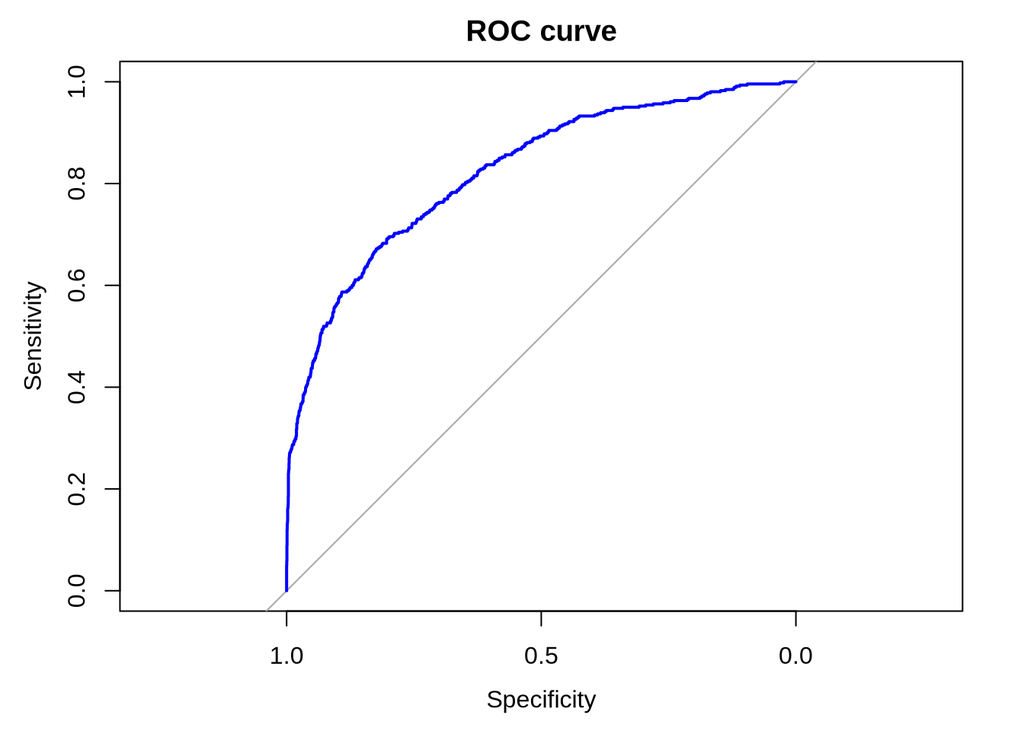

```r
roc_final <- roc(dataset_rf$EVENT, predict(final_model, dataset_rf)$predicted)
auc_final <- auc(roc_final)
plot(roc_final, col = "blue", lwd = 2, main = "ROC curve")
```

```r
print(auc_final)
```

```
Area under the curve: 0.824
```

In this case the random forest model is applied to our whole dataset with the parameters explained above. This resulted in a well-performing model on our data with an AUC of 0.824.

In this case the random forest model is applied to our whole dataset with the parameters explained above. This resulted in a well-performing model on our data with an AUC of 0.824. We see from the value of this AUC that it is a bit ‘too’ good. This is because in this graph, we are testing the full final model, and are not separating the test and training data. This we do in the previous graph above.

# Cox regression

```r
library(tidyverse) # For data manipulation
library(knitr) # For tables
library(caret) # For model training
library(pROC) # For ROC analysis
library(MASS) # For stepAIC
library(boot) # For bootstrapping
library(survival) # For survival analysis
library(rms) # For validating Cox model
library(glmnet) # For lasso and ridge regression
library(data.table) # For faster CSV read
```

### Load dataset (and re-encode variables, not needed)

```r
Patients <- fread("SMARTc.csv", sep = ";")
final_patients <- Patients %>%
    mutate(log_CREAT = log(CREAT)) %>%
    subset(select = -c(HISTCARD, HISTCAR2, CREAT))
```

# Cox model with stepwise selection

```r
surv_object <- Surv(time = final_patients$TEVENT, event = final_patients$EVENT)
surv_fit_formula <- surv_object ~ SEX + DIABETES + SYSTH + DIASTH + WEIGHT + BMI + LDL + TRIG + log_CREAT

initial_cox_model <- coxph(surv_fit_formula, data = final_patients)
stepwise_cox_model <- stepAIC(initial_cox_model, direction = "backward")
```

```r
summary(stepwise_cox_model)
```

```
Call:
coxph(formula = surv_object ~ SEX + DIABETES + SYSTH + DIASTH +
    WEIGHT + LDL + log_CREAT, data = final_patients)

  n= 3873, number of events= 460

               coef exp(coef)  se(coef)      z Pr(>|z|)
SEX       -0.379332  0.684318  0.129589 -2.927  0.00342 **
DIABETES   0.304320  1.355703  0.108448  2.806  0.00501 **
SYSTH      0.017114  1.017261  0.002586  6.618 3.65e-11 ***
DIASTH    -0.021928  0.978311  0.005270 -4.161 3.17e-05 ***
WEIGHT    -0.009021  0.991020  0.004044 -2.231  0.02570 *
LDL        0.102637  1.108089  0.046872  2.190  0.02855 *
log_CREAT  1.001529  2.722440  0.103075  9.717  < 2e-16 ***
---
Signif. codes:  0 '***' 0.001 '**' 0.01 '*' 0.05 '.' 0.1 ' ' 1

          exp(coef) exp(-coef) lower .95 upper .95
SEX          0.6843     1.4613    0.5308    0.8822
DIABETES     1.3557     0.7376    1.0961    1.6768
SYSTH        1.0173     0.9830    1.0121    1.0224
DIASTH       0.9783     1.0222    0.9683    0.9885
WEIGHT       0.9910     1.0091    0.9832    0.9989
LDL          1.1081     0.9025    1.0108    1.2147
log_CREAT    2.7224     0.3673    2.2244    3.3319

Concordance= 0.648  (se = 0.014 )
Likelihood ratio test= 160  on 7 df,   p=<2e-16
Wald test            = 193.4  on 7 df,   p=<2e-16
Score (logrank) test = 202.6  on 7 df,   p=<2e-16
```

The “Coef” represents the levels of risk. With a negative coefficient, we know the variable has a decreased risk on the event, and a positive coefficient indicates an increased risk on EVENT. Subsequently, when looking at exp(coef), we conclude that a ratio bigger than 1 means an increased risk and a ration smaller than 1 means a decreased risk. For instance, we see that diabetes has a positive coefficient 0.304, with ratio 1.355. People with diabetes thus have a 35.5% higher risk of EVENT, which is also significant with p=0.00501

Below, we see that for instance for log_CREAT, the hazard ratio is 2.722 with a 95% confidence interval of (2.224, 3.331).

# Extracting coefficients from the final model

```r
final_coefficients <- coef(stepwise_cox_model)
print(final_coefficients)
```

```
         SEX     DIABETES        SYSTH       DIASTH       WEIGHT          LDL
-0.379332290  0.304319946  0.017113555 -0.021928093 -0.009020544  0.102636592
   log_CREAT
 1.001528558
```

The coefficients above are log-hazard ratios, and we can calculate the hazard ratio by exponentiating each coefficient: Hazard Ratio (HR) = $e^{\text{coefficient}}$

This means per variable, that risk is increased or decreased if the predictor variable increased. Below, the changes and Hazard ratios per variable are shortly outlined.

- SEX (-0.379): $e^{-0.379}$ = 0,684. This means that a 1-unit change (male to female) lowers the risk of occurring event with around 32%.
- DIABETES (0.304): $e^{0.304}$ = 1.355. This means that having diabetes increases the hazard. Having diabetes is associated with 35.5% higher risk of the event occurring.
- SYSTH (0.017): $e^{0.017}$ = 1.017. This indicates a 1.7% risk increase for each unit increase of the systolic blood pressure.
- WEIGHT (-0.009): $e^{-0.009}$ = 0.991. For interpretation of this, each unit of increase in weight means a 0.9% lower risk of event occurring.
- LDL (0.103): $e^{0.103}$ = 1.109. This tells us that there’s a 10.9% higher risk of event occurring for each unit increase n LDL cholesterol.
- log_CREAT (1.002) = $e^{1.002}$ = 2.724. This indicates a 172.4% higher risk of event occurring for each 1-unit increase of the log-transformed creatinine.

Concluding. Some factors like diabetes, LDL and creatinine significantly increase the risk of occurring when unit of measuring change, while others might reduce the risk. Understanding how these variables interact with the outcome helps guide medical or practical decisions related to the modeled event.

# Calculate concordance index for the final model

```r
final_surv <- Surv(time = final_patients$TEVENT, event = final_patients$EVENT)
final_surv_fit_formula <- final_surv ~ predict(stepwise_cox_model, newdata = final_patients)
final_cox_model <- coxph(final_surv_fit_formula, data = final_patients)
concordance_index <- final_cox_model$concordance
print(paste("Concordance Index:", concordance_index))
```

```
[1] "Concordance Index: 712600"
[2] "Concordance Index: 386383"
[3] "Concordance Index: 0"
[4] "Concordance Index: 87"
[5] "Concordance Index: 0"
[6] "Concordance Index: 0.648417673430799"
[7] "Concordance Index: 0.0137701160851522"
```

We see from the output 7 different concordance levels. We see that the 1st to the 5th are not possible and the 7th isn’t possible either. We conclude to have a concordance level of 0.648

# Summary of the final model and exponentiated coefficients

```r
summary(final_cox_model)
```

```
Call:
coxph(formula = final_surv_fit_formula, data = final_patients)

  n= 3873, number of events= 460

                                                         coef exp(coef)
predict(stepwise_cox_model, newdata = final_patients) 1.00000   2.71828
                                                      se(coef)     z Pr(>|z|)
predict(stepwise_cox_model, newdata = final_patients)  0.07191 13.91   <2e-16

predict(stepwise_cox_model, newdata = final_patients) ***
---
Signif. codes:  0 '***' 0.001 '**' 0.01 '*' 0.05 '.' 0.1 ' ' 1

                                                      exp(coef) exp(-coef)
predict(stepwise_cox_model, newdata = final_patients)     2.718     0.3679
                                                      lower .95 upper .95
predict(stepwise_cox_model, newdata = final_patients)     2.361      3.13

Concordance= 0.648  (se = 0.014 )
Likelihood ratio test= 160  on 1 df,   p=<2e-16
Wald test            = 193.4  on 1 df,   p=<2e-16
Score (logrank) test = 185.2  on 1 df,   p=<2e-16
```

```r
exp(final_coefficients)
```

```
      SEX  DIABETES     SYSTH    DIASTH    WEIGHT       LDL log_CREAT
0.6843182 1.3557027 1.0172608 0.9783106 0.9910200 1.1080886 2.7224401
```

# Cross-validation of the Cox model

```r
set.seed(123)
folds <- createFolds(final_patients$EVENT, k = 10, list = TRUE, returnTrain = TRUE)
cv_concordance_indices <- numeric(10)

for (i in 1:10) {
    # Split the data into training and testing sets
    train_data <- final_patients[folds[[i]], ]
    test_data <- final_patients[-folds[[i]], ]

    # Create the survival object for training data
    surv_train <- Surv(time = train_data$TEVENT, event = train_data$EVENT)
    surv_fit_formula <- surv_train ~ SEX + DIABETES + SYSTH + DIASTH + WEIGHT + BMI + LDL + TRIG + log_CREAT

    # Fit the Cox model on the training data
    cox_model <- coxph(surv_fit_formula, data = train_data)

    # Predict on the test data
    test_surv <- Surv(time = test_data$TEVENT, event = test_data$EVENT)
    predictions <- predict(cox_model, newdata = test_data)

    cv_concordance_indices[i] <- coxph(test_surv ~ predictions, data = test_data)$concordance
}

mean_concordance_cv <- mean(cv_concordance_indices)
mean_concordance_cv
```

[output not shown]

```r
bootstrap_cox_model <- function(data, indices) {
    resampled_data <- data[indices, ]
    surv_object <- Surv(time = resampled_data$TEVENT, event = resampled_data$EVENT)
    surv_fit_formula <- surv_object ~ SEX + DIABETES + SYSTH + DIASTH + WEIGHT + BMI + LDL + TRIG + log_CREAT

    initial_cox_model <- coxph(surv_fit_formula, data = resampled_data)
    stepwise_model <- stepAIC(initial_cox_model, direction = "backward", trace = FALSE)
    all_vars <- colnames(data)[-c(1, 2)]
    selected_vars <- names(coef(stepwise_model))

    # Create a binary vector: 1 if the variable is included, 0 otherwise
    inclusion_vector <- as.integer(all_vars %in% selected_vars)

    return(inclusion_vector)
}

# Set the number of bootstrap samples
set.seed(123)
n_bootstrap_samples <- 100

# Run bootstrapping
bootstrap_results <- boot(data = final_patients, statistic = bootstrap_cox_model, R = n_bootstrap_samples)
```

# Analyze results: Create a table of inclusion frequencies

```r
inclusion_frequencies <- colMeans(bootstrap_results$t) # Get inclusion proportions
inclusion_variables <- colnames(final_patients)[-c(1, 2)]
inclusion_frequencies <- data.frame(Variable = inclusion_variables, Proportion = inclusion_frequencies)
inclusion_frequencies
```

| Variable | Proportion |
| --- | --- |
| SEX | 0.94 |
| AGE | 0.00 |
| DIABETES | 0.84 |
| CEREBRAL | 0.00 |
| CARDIAC | 0.00 |
| AAA | 0.00 |
| PERIPH | 0.00 |
| STENOSIS | 0.00 |
| SYSTBP | 0.00 |
| DIASTBP | 0.00 |

[output cut: 17 more lines]

# Optional: Visualize the inclusion frequencies

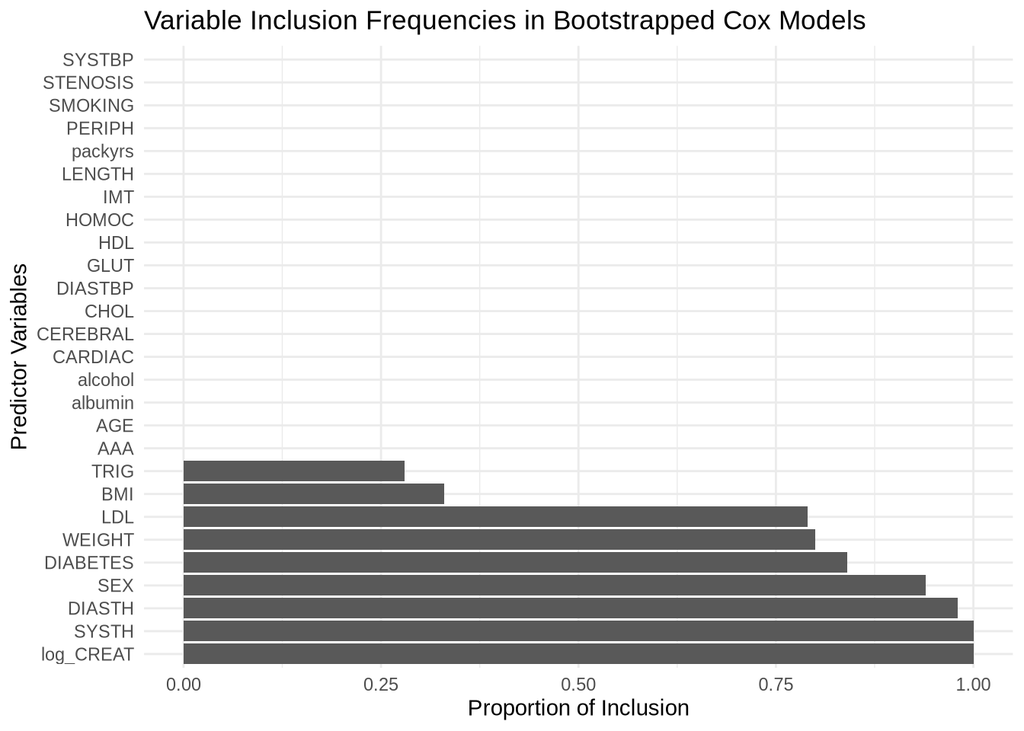

```r
ggplot(inclusion_frequencies, aes(x = reorder(Variable, -Proportion), y = Proportion)) +
    geom_bar(stat = "identity") +
    coord_flip() +
    labs(
        title = "Variable Inclusion Frequencies in Bootstrapped Cox Models",
        x = "Predictor Variables",
        y = "Proportion of Inclusion"
    ) +
    theme_minimal()
```

This code and visualisations above involves bootstrapping the Cox proportional hazards model multiple times, and tracks how frequently each variable is selected (i.e., included) in the model across different bootstrap iterations. The variable inclusion frequency plot shows how often each predictor was selected across multiple bootstrapped Cox models. It can be seen that variables like SYSTH, log_CREAT, and SEX were included more frequently, indicating they have a stronger or more consistent effect on the outcome.